# A Price Analysis of Differences between Fresh and Canned Fruit

Chen Chen, Nathaniel Dreyfus, Ally Frye

2024-12-11

## Introduction

As more and more people begin to become aware of what is going into processed food, trends to eat organically have skyrocketed since the 1950s. With this increase in popularity, access to fresh, cheap produce is more important than ever. In this paper we plan to examine the relationship between the form in which fruit is sold (canned and fresh) and its retail price in different types of fruits. Before beginning this test, we hypothesized that fresh fruit will be the most expensive based on the rationale that fresh fruit has the shortest shelf life of the forms - since these fruits go bad, there is a higher turnover rate, and demand. After running this test, we failed to find strong evidence that fresh fruit is more expensive on average than canned fruit. This result didn’t match our expectations and calls for further investigation. We might need to refine our testing methods in the future to get clearer answers.

### Background

#### Data Source and Collection

The data for this study was sourced from the USDA Economic Research Service (ERS), which averaged retail prices from various contributors. Key data was collected via Circana, a global organization analyzing consumer behavior, using weekly sales reports from grocery stores, supermarkets, and other retail establishments. Additional data came from the Agricultural Research Services and the Food Price Outlook. Originally, this dataset aimed to estimate the cost of a balanced diet for the average American family.

#### Key Variables

- *Fruit:* types of fruit products.
- *Form:* the form in which the fruit product is sold. Fruits identified for pricing include fresh fruits, as well as fruit juices, and processed fruits (canned, fresh, frozen, or dried products).
- *RetailPrice:* each fruit’s average retail price. Sales were calculated by weight and by dollars, aggregating across all stores. Average retail prices per pound or per pint were then estimated for all products as the ratio of aggregated sales in dollars to aggregated sales by weight.

#### VISUAL

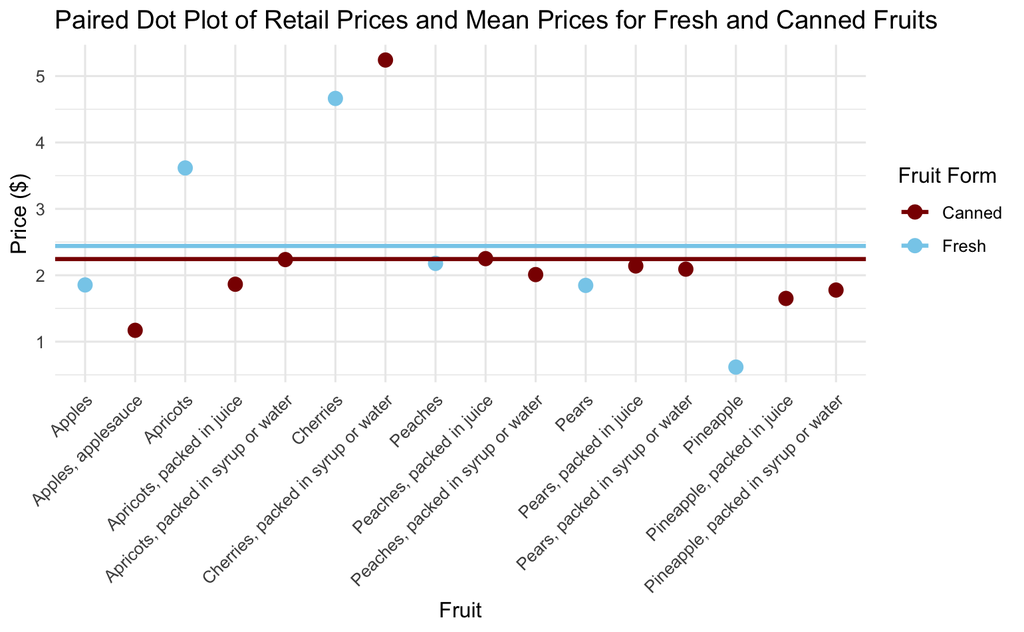

## Statistical Analysis

- In order to answer our question, does the form of fruit significantly affect its retail price, and specifically, is there a difference in the mean retail prices between two forms of fruits; we performed an inference on the difference of two population means. Our parameters are the mean retail prices of 2 selected forms of fruits - canned and fresh.

*Our methodology is the hypothesis testing for the difference of two means.*

### *Model Statement:*

- Let $X_i$ be the observed retail price of the fresh fruits.
- Let $Y_i$ be the observed retail price of the canned fruits.
- Let $𝜇_𝑥$ and $𝜎_𝑥$ be the true average and standard deviation of the true distribution $D_x$ of the canned fruits.
- Let $𝜇_y$ and $𝜎_y$ be the true average and standard deviation of the true distribution $𝐷_y$ of the canned fruits.
- Finally, we assume that the two samples are independent.

### *Hypotheses*

- *The null hypothesis* is that there is no difference between the mean retail prices of fresh fruits and canned fruits.

$$𝐻_0: 𝜇𝑥 = 𝜇y,\quad or\quad equivalently: 𝐻0: \mu_x - \mu_y = 0$$

$$H_a: 𝜇𝑥 - 𝜇y ≠ 0$$

## Discussion

### *Limitations & Future Research*

- In this test we used a limited amount of data as we did not have access to previous years of data. We also did not include data on frozen or dried fruit in order to isolate the difference specifically between fresh and canned fruit.
- In future research scientists should aim to examine the trends of fruit prices throughout multiple years to see if our thesis holds true throughout different years. Studying the other forms of fruit would also bring insight to how fresh produce prices compare to forms beside canned.

## References

- https://www.cbsnews.com/boston/news/question-everything-why-is-healthy-food-so-expensive/
- https://www.aecf.org/blog/communities-with-limited-food-access-in-the-united-states
- https://policymatters.illinois.edu/does-food-cost-more-in-food-deserts/